# The Price of Risk Drives the Business Cycle

Graduate Student Summer Seminar Series

Tobias Adrian

International Monetary Fund<sup>1</sup>

Matthew DeHaven

Brown University

Fernando Duarte

Brown University

June 27, 2024

<sup>1</sup>The views expressed here are the authors’ and are not necessarily representative of the views of the International Monetary Fund, its Management, or its Executive Directors.

## Co-movement over the Business Cycle

Empirically, we observe co-movement across macro variables over the business cycle.

**Key Question in Macroeconomics:** What drives this co-movement?

- A single shock
- A common propagation mechanism

We show that…

- the “price of risk” is a common propagation mechanism that can be used to discern between models of the business cycle.

## Outline

0. Result preview
1. What is the price of risk?
2. Vector Auto Regression (VAR) setup
   - Identification problem
   - Instrumenting with the VFCI
3. Estimate the price of risk internal to the VAR
   - Looks like the business cycle
4. Interpretation and next steps

## Result Preview: *quacks* like a business cycle

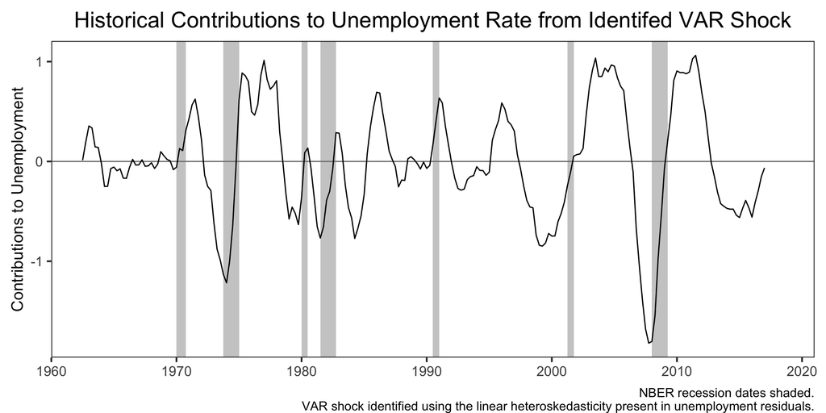

## What is the Price of Risk?

- A measure of the amount of compensation required to hold an additional unit of risk (volatility).

The SDF (stochastic discount factor) can be decomposed…

$$\begin{align}
\text{SDF}_{t+1} = \mathbb{E}_t[\text{SDF}_{t+1}] + \text{Vol}_t[{\text{SDF}_{t+1}}] \epsilon_{t+1}
\end{align}$$

- $\mathbb{E}_t[\text{SDF}_{t+1}]$ is the expected mean,
- $\text{Vol}_t[{\text{SDF}_{t+1}}]$ is the expected volatility (the price of risk),
- $\epsilon_{t+1}$ is an unforseen innovation (structural shocks).

## Estimating the Price of Risk

In most macro models, the Euler equation links the SDF to marginal utility:

$$\text{SDF}_{t+1} = \beta \left(\frac{C_{t+1}}{C_t}\right)^{-\gamma}$$

Leveraging this, we can estimate the price of risk using changes in the volatility of consumption growth (or a similar measure).

## VFCI is an Estimate of the Market Price of Risk

Volatility Financial Conditions Index (VFCI) is **a** measure of the price of risk.

- Introduced in Adrian, Duarte, and Iyer (WP)

The VFCI is estimated as the predictable

- changes in the volatility of GDP growth,
- using financial returns.

## VFCI

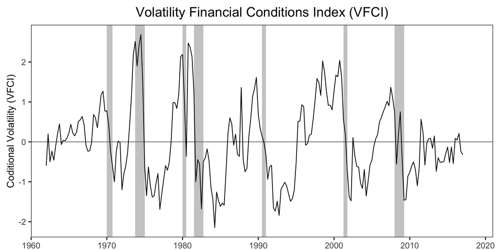

## Mean - Vol Relationship

A key empirical result is that the price of risk (measured by the VFCI), is linearly linked to the conditional mean.

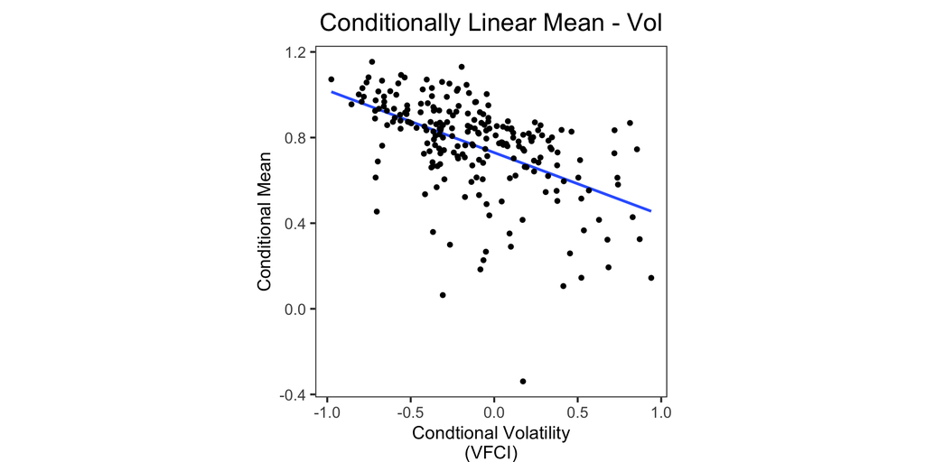

We will leverage this relationship to identify the business cycle in our VAR.

## VAR Setup

A strucutral VAR with $p$ lags and $k$ variables in vector $y_t$,
$$B_0 y_t = B_1 y_{t-1} + . . . + B_p y_{t-p} + w_t$$

the shocks $w_t$ are assumed to be orthogonal and to have unit variance.

Empirically, only the following $A_i$ matrices and reduced form residuals, $u_t$, are observed,

$$y_t = \underbrace{B_0^{-1}B_1}_{A_1} y_{t-1} + \dots + \underbrace{B_0^{-1}B_p}_{A_p} y_{t-p} + \underbrace{B_0^{-1}w_t}_{u_t}$$

## Identification Problem

Need to identify a column of the impact matrix $B_0^{-1}$ to back out a structural shock:

$$u_t = B_0^{-1} w_t$$

We will start by using the VFCI as an instrument,

$$\begin{align}
(1)\ \ \ \ \ \mathbf{E}[\text{VFCI}_t w_{1,t}^\prime] &= \alpha \neq 0
\\
(2)\ \ \ \mathbf{E}[\text{VFCI}_t w_{2:k,t}^\prime] &= 0
\end{align}$$

Where (1) is a relavence condition and (2) is an exogeneity condition.

## Externally Instrumented Price of Risk

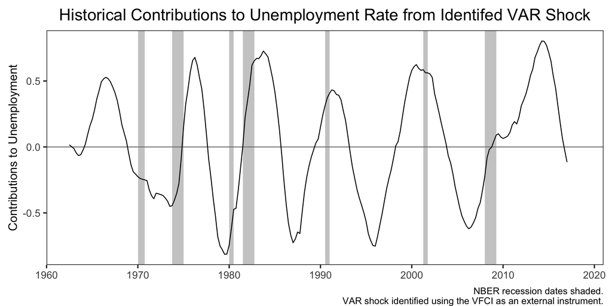

## Mean-Vol Relationship in the VAR

Taking our VAR with $p$ lags and $k$ variables in vector $y_t$,

$$y_t = A_1 y_{t-1} + \text{ ... } + A_p y_{t-p} + u_t$$

The log variance of the residual is then, $\sigma_t = \log\left(\widehat{u}_t^2\right)$.

Then estimate,

$$\sigma_t = \alpha y_{t} + \varepsilon_t$$

The mean-vol relationship is between $\widehat{y}_t$ and $\widehat{\sigma}_t$.

There are $k$ mean-vol relationships in the VAR, one for each variable.

## Mean-Vol Relationship in the VAR

Using unemployment, we can see a strong linear relationship between the conditional mean and the conditional volatility.

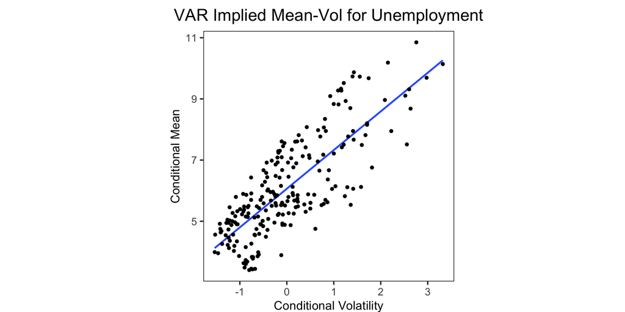

## VAR Implied Price of Risk

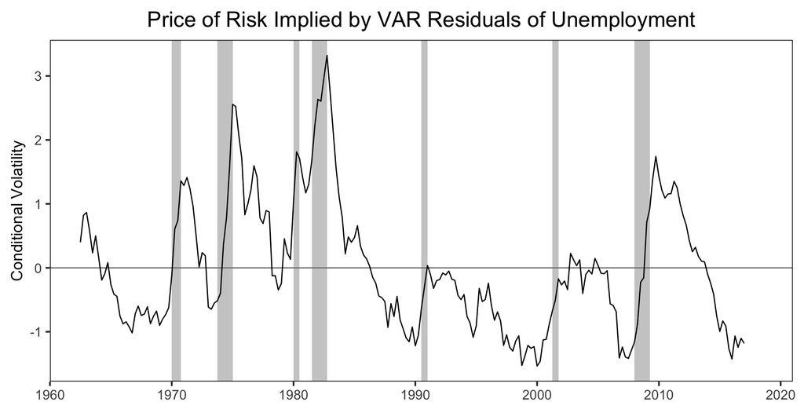

## Result review: *quacks* like a business cycle

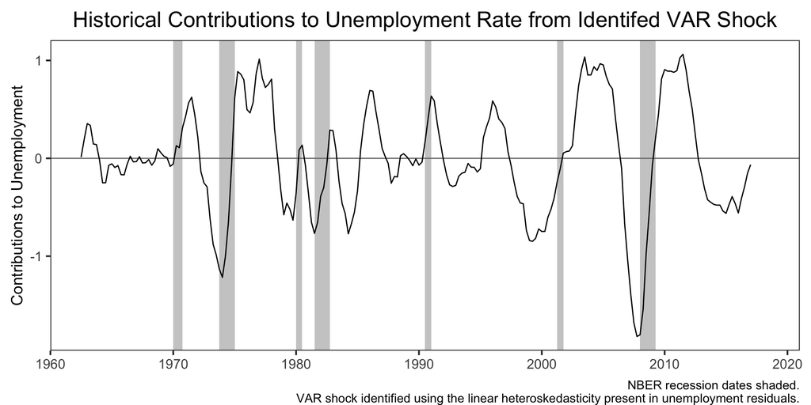

## Matches the “Business Cycle Anatomy” Shock

Angeletos et al. (2020) identify a “Main Business Cycle (MBC) Shock” which drives most of the unforecasted variation in unemployment.

Our internal VAR shock has a correlation with the MBC shock of $0.75$.

## Matches the “Business Cycle Anatomy” Shock

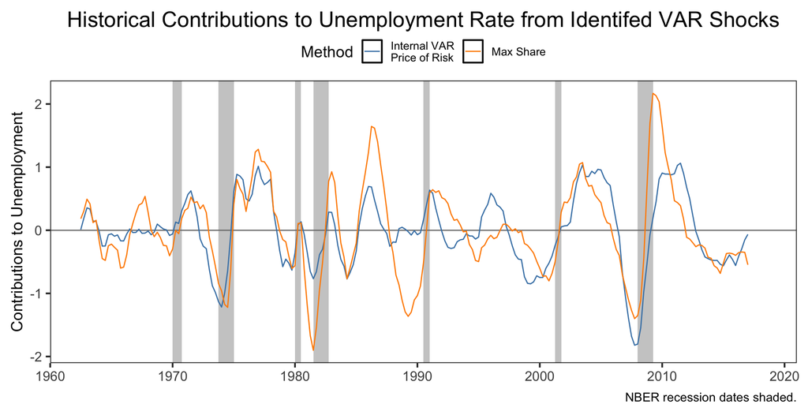

## A New Business Cycle Fact

We show a new key feature of business cycles:

- the price of risk comoves with the mean of macro varaibles during the cycle.

This is not a feature in Real Business Cycle (RBC) or New Keynesian models.

You need a model that links second moments (volatilities) to first moments.

## Financial Conditions Propagate the Business Cycle

There exists a general equilibrium structural model that is consistent with

- the existence of the mean-vol relationship in the empirical data,
- and that the price of risk comoves with the business cycle.

This model has financial conditions aggregate, amplify, and propagate disparate shocks to the rest of the economy.

- Driven by a financial friction: the value-at-risk constraint.

## Conclusion

- Can use the VFCI or an internal VAR implied price of risk to identify a shock.
  - Looks like a business cycle.
  - Matches the “Main Business Cycle” shock.
- Adds a new empirical fact for distinguishing models of the business cycle.
- Consistent with a structural model where financial frictions create a common propagation mechanism through the price of risk.

# Appendix

## Comparing Internal and External Price of Risk

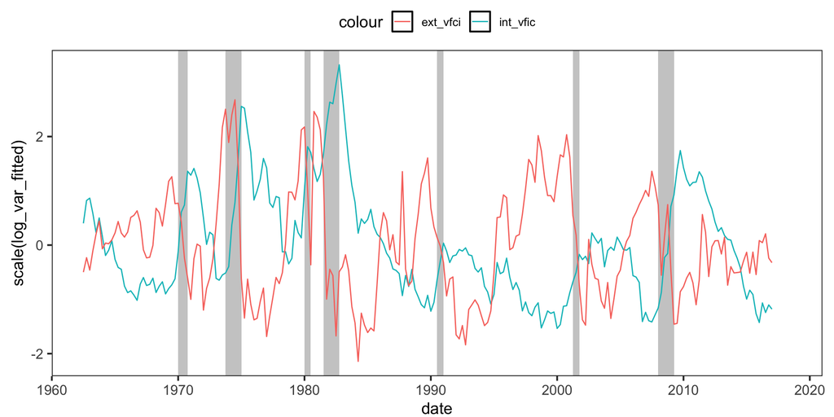

## Appendix: IRF of HVAR

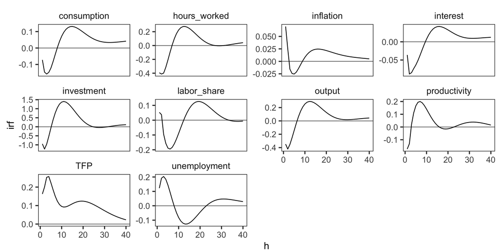